# Aplicación 2.5: Variaciones del modelo básico

# Forma funcional polinómica: Curva de costes en el sector textil

En esta aplicación trabajaremos con datos de series temporales que consisten en 28 observaciones mensuales sobre los costes totales ($COST$) y la cantidad producida ($Q$) de una empresa del sector textil.

Se estimará por MCO el siguiente modelo de regresión lineal asociado a la [curva de costes](https://en.wikipedia.org/wiki/Cost_curve) de la empresa:

$$COST_{t} = \beta_1 + \beta_2 Q_{t} + \beta_3 Q_{t}^2 + e_{t}$$

es decir, se supondrá que los costes totales son una función polinómica (cuadrática) de la cantidad producida.

**Código R**

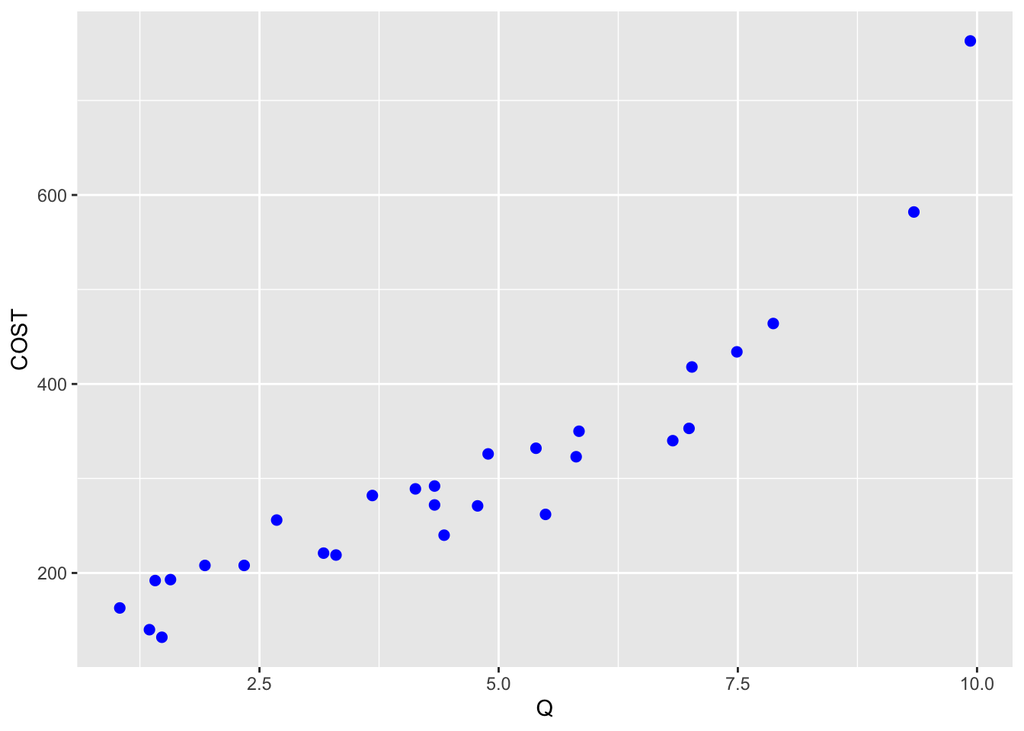

```r
# Lectura de librerías
library(tidyverse)
# Lectura de datos
COST_TEXT <- read_csv("data/COST_TEXT.csv")
# Gráfica de los valores observados
ggplot(COST_TEXT, aes(x = Q, y = COST)) + geom_point(size = 2, color = "blue")
```

```r
# Estimación del modelo
model <- lm(formula = COST ~ Q + I(Q^2), data = COST_TEXT)
# fórmula alternativa: formula = COST ~ poly(Q, 2, raw = TRUE)
summary(model)
```

```
Call:
lm(formula = COST ~ Q + I(Q^2), data = COST_TEXT)

Residuals:
    Min      1Q  Median      3Q     Max
-59.710 -20.401   3.813  18.627  84.682

Coefficients:
            Estimate Std. Error t value Pr(>|t|)
(Intercept)  185.154     26.461   6.997 2.47e-07 ***
Q             -8.461     11.603  -0.729    0.473
I(Q^2)         5.853      1.112   5.264 1.88e-05 ***
---
Signif. codes:  0 '***' 0.001 '**' 0.01 '*' 0.05 '.' 0.1 ' ' 1

Residual standard error: 37.74 on 25 degrees of freedom
Multiple R-squared:  0.9282,    Adjusted R-squared:  0.9224
F-statistic: 161.6 on 2 and 25 DF,  p-value: 5.043e-15
```

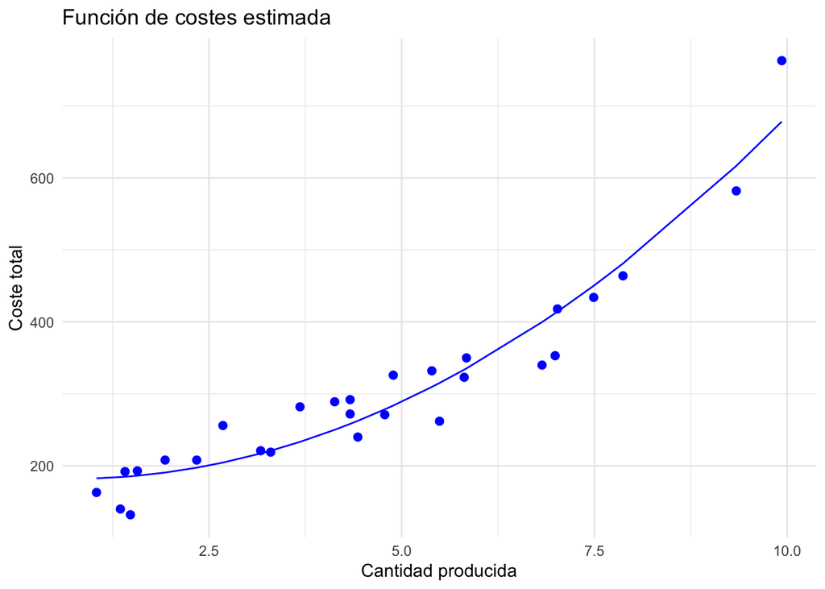

```r
# Función de costes estimada
ggplot(data = COST_TEXT, aes(x = Q, y = COST)) +
  geom_line(aes(y = predict(model,
                            newdata = data.frame(Q = Q, Q2 = Q^2))),
            color = "blue") +
  geom_point(size = 2, color = "blue") +
  labs(title = "Función de costes estimada",
       x = "Cantidad producida",
       y = "Coste total") +
  theme_minimal()
```

**Código Python**

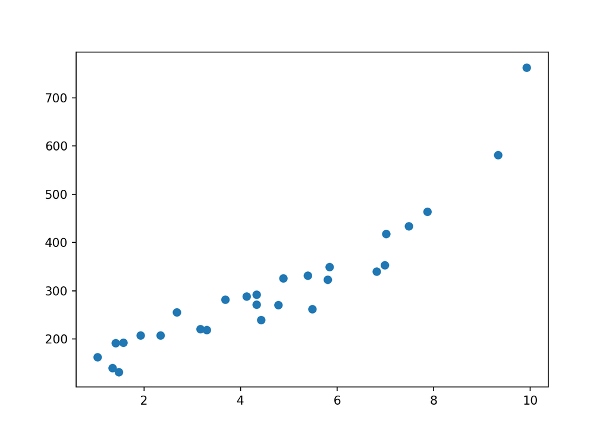

```python
# Lectura de librerías
import numpy as np
import pandas as pd
import matplotlib.pyplot as plt
import statsmodels.formula.api as smf
# Lectura de datos
COST_TEXT = pd.read_csv('data/COST_TEXT.csv')
# Gráfica de los valores observados
plt.scatter(COST_TEXT['Q'], COST_TEXT['COST'])
plt.show()
```

```python
# Estimación del modelo
model = smf.ols(formula = 'COST ~ Q + I(Q**2)', data = COST_TEXT).fit()
# fórmula alternativa: formula = COST ~ Q + np.power(Q, 2)
print(model.summary())
```

```
                            OLS Regression Results
==============================================================================
Dep. Variable:                   COST   R-squared:                       0.928
Model:                            OLS   Adj. R-squared:                  0.922
Method:                 Least Squares   F-statistic:                     161.6
Date:                Sun, 09 Feb 2025   Prob (F-statistic):           5.04e-15
Time:                        13:31:52   Log-Likelihood:                -139.80
No. Observations:                  28   AIC:                             285.6
Df Residuals:                      25   BIC:                             289.6
Df Model:                           2
Covariance Type:            nonrobust
==============================================================================
                 coef    std err          t      P>|t|      [0.025      0.975]
------------------------------------------------------------------------------
Intercept    185.1539     26.461      6.997      0.000     130.656     239.652
Q             -8.4608     11.603     -0.729      0.473     -32.358      15.436
I(Q ** 2)      5.8535      1.112      5.264      0.000       3.563       8.143
==============================================================================
Omnibus:                        0.128   Durbin-Watson:                   1.805
Prob(Omnibus):                  0.938   Jarque-Bera (JB):                0.266
Skew:                           0.138   Prob(JB):                        0.875
Kurtosis:                       2.610   Cond. No.                         150.
==============================================================================

Notes:
[1] Standard Errors assume that the covariance matrix of the errors is correctly specified.
```

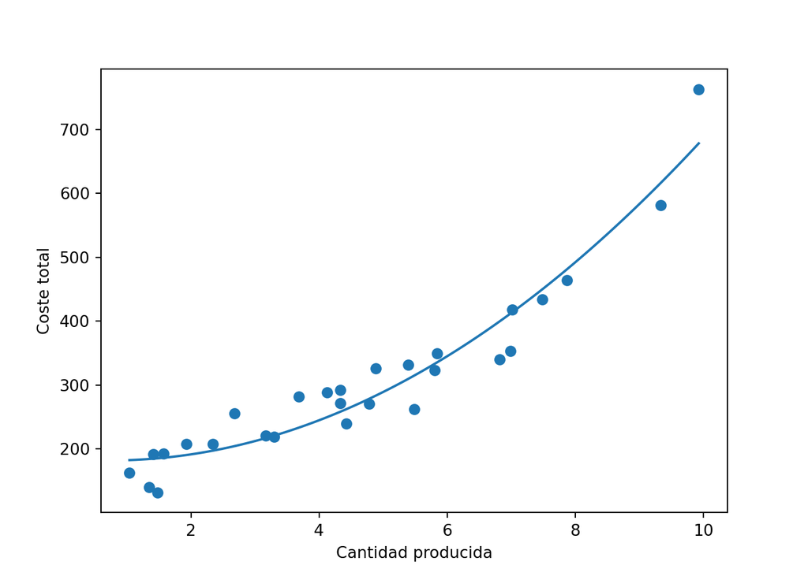

```python
# Función de costes estimada
Q_min = COST_TEXT['Q'].min()
Q_max = COST_TEXT['Q'].max()
Q_values = np.linspace(Q_min, Q_max, num=100)
C_values=model.params[0] + model.params[1]*Q_values + model.params[2]*Q_values**2
plt.plot(Q_values, C_values)
plt.scatter(COST_TEXT['Q'], COST_TEXT['COST'])
plt.xlabel('Cantidad producida')
plt.ylabel('Coste total')
plt.show()
```

# Términos de interacción: Efectos diferenciados de la publicidad sobre las ventas

Supongamos que somos consultores contratados por un cliente para asesorarle sobre cómo mejorar las ventas de un determinado producto. No es posible para el empresario incrementar las ventas del producto de una forma directa (vía mejoras de la calidad o reducciones en el precio, por ejemplo), sino sólo de forma indirecta a través de [campañas publicitarias](https://es.wikipedia.org/wiki/Publicidad). La idea es construir un modelo que pueda usarse para predecir las ventas en función de la inversión realizada en publicidad.

Los datos que utilizaremos consisten en las ventas totales ($VENTAS$) del producto analizado (en miles de unidades) en 200 mercados diferentes, junto con los gastos realizados (en miles de dólares) en publicitar el producto en cada uno de esos mercados en dos medios de difusión diferentes, televisión ($TV$) y radio ($RADIO$).

Podría proponerse, en primer lugar, un modelo de regresión estándar de tipo aditivo como el siguiente,

$$VENTAS_{i} = \beta_1 + \beta_2 TV_{i} + \beta_3 RADIO_{i} + e_{i}$$

en el que el efecto de un cambio unitario en una variable explicativa (*ceteris paribus*) sobre la variable de respuesta no depende de los valores de las otras variables explicativas. En nuestro caso, esto implica que el efecto sobre las ventas de un incremento en el gasto de publicidad en un determinado medio (televisión o radio) es constante y, por tanto, independiente de la cantidad gastada en los otros medios de promoción.

Si se contempla la posibilidad de que existan *efectos sinergia*, es decir, que el gasto realizado en un medio, por ejemplo, la radio, incremente la efectividad del gasto en otro medio, por ejemplo, la televisión, hay que generalizar el modelo inicial permitiendo la aparición de términos de interacción:

$$VENTAS_{i} = \beta_1 + \beta_2 TV_{i} + \beta_3 RADIO_{i} + \beta_4 (TV_i*RADIO_i) + e_{i}$$

**Código R**

```r
# Lectura de librerías
library(tidyverse)
library(plotly)
# Lectura de datos
PUB_VENTAS <- read_csv("data/PUB_VENTAS.csv")
# Estimación del modelo lineal
model1 <- lm(data = PUB_VENTAS, formula = VENTAS ~ TV + RADIO)
summary(model1)
```

```
Call:
lm(formula = VENTAS ~ TV + RADIO, data = PUB_VENTAS)

Residuals:
    Min      1Q  Median      3Q     Max
-8.7977 -0.8752  0.2422  1.1708  2.8328

Coefficients:
            Estimate Std. Error t value Pr(>|t|)
(Intercept)  2.92110    0.29449   9.919   <2e-16 ***
TV           0.04575    0.00139  32.909   <2e-16 ***
RADIO        0.18799    0.00804  23.382   <2e-16 ***
---
Signif. codes:  0 '***' 0.001 '**' 0.01 '*' 0.05 '.' 0.1 ' ' 1

Residual standard error: 1.681 on 197 degrees of freedom
Multiple R-squared:  0.8972,    Adjusted R-squared:  0.8962
F-statistic: 859.6 on 2 and 197 DF,  p-value: < 2.2e-16
```

```r
# Gráfica del ajuste
plot_ly(data = PUB_VENTAS) %>%
    add_trace(x = ~TV, y = ~RADIO, z = ~VENTAS,
              mode = "markers", type = "scatter3d",
              marker = list(size = 5, color = "blue", symbol = 104),
              name = "Observaciones") %>%
    add_trace(z = model1$fitted.values, x = ~TV, y = ~RADIO,
              type = "mesh3d",
              name = "Valores ajustados") %>%
    layout(scene = list(xaxis = list(title = 'TV'),
                        yaxis = list(title = 'RADIO'),
                        camera = list(eye = list(x = -1.5, y = 1.5, z = 0)),
                        zaxis = list(title = 'VENTAS'), aspectmode='cube'))
```

[interactive chart not shown]

```r
# Estimación del modelo con interacción
model2 <- lm(data = PUB_VENTAS, formula = VENTAS ~ TV * RADIO)
summary(model2)
```

```
Call:
lm(formula = VENTAS ~ TV * RADIO, data = PUB_VENTAS)

Residuals:
    Min      1Q  Median      3Q     Max
-6.3366 -0.4028  0.1831  0.5948  1.5246

Coefficients:
             Estimate Std. Error t value Pr(>|t|)
(Intercept) 6.750e+00  2.479e-01  27.233   <2e-16 ***
TV          1.910e-02  1.504e-03  12.699   <2e-16 ***
RADIO       2.886e-02  8.905e-03   3.241   0.0014 **
TV:RADIO    1.086e-03  5.242e-05  20.727   <2e-16 ***
---
Signif. codes:  0 '***' 0.001 '**' 0.01 '*' 0.05 '.' 0.1 ' ' 1

Residual standard error: 0.9435 on 196 degrees of freedom
Multiple R-squared:  0.9678,    Adjusted R-squared:  0.9673
F-statistic:  1963 on 3 and 196 DF,  p-value: < 2.2e-16
```

```r
# Gráfica del ajuste
plot_ly(data = PUB_VENTAS) %>%
    add_trace(x = ~TV, y = ~RADIO, z = ~VENTAS,
              mode = "markers", type = "scatter3d",
              marker = list(size = 5, color = "blue", symbol = 104),
              name = "Observaciones") %>%
    add_trace(z = model2$fitted.values, x = ~TV, y = ~RADIO, type = "mesh3d",
              name = "Valores ajustados") %>%
    layout(scene = list(xaxis = list(title = 'TV'),
                        yaxis = list(title = 'RADIO'),
                        camera = list(eye = list(x = -1.5, y = 1.5, z = 0)),
                        zaxis = list(title = 'VENTAS'), aspectmode='cube'))
```

[interactive chart not shown]

**Código Python**

```python
# Lectura de librerías
import numpy as np
import pandas as pd
import matplotlib.pyplot as plt
import statsmodels.formula.api as smf
# Lectura de datos
PUB_VENTAS = pd.read_csv('data/PUB_VENTAS.csv')
# Estimación del modelo lineal
model1 = smf.ols('VENTAS ~ TV + RADIO', data=PUB_VENTAS)
print(model1.fit().summary())
```

```
                            OLS Regression Results
==============================================================================
Dep. Variable:                 VENTAS   R-squared:                       0.897
Model:                            OLS   Adj. R-squared:                  0.896
Method:                 Least Squares   F-statistic:                     859.6
Date:                Sun, 09 Feb 2025   Prob (F-statistic):           4.83e-98
Time:                        13:31:53   Log-Likelihood:                -386.20
No. Observations:                 200   AIC:                             778.4
Df Residuals:                     197   BIC:                             788.3
Df Model:                           2
Covariance Type:            nonrobust
==============================================================================
                 coef    std err          t      P>|t|      [0.025      0.975]
------------------------------------------------------------------------------
Intercept      2.9211      0.294      9.919      0.000       2.340       3.502
TV             0.0458      0.001     32.909      0.000       0.043       0.048
RADIO          0.1880      0.008     23.382      0.000       0.172       0.204
==============================================================================
Omnibus:                       60.022   Durbin-Watson:                   2.081
Prob(Omnibus):                  0.000   Jarque-Bera (JB):              148.679
Skew:                          -1.323   Prob(JB):                     5.19e-33
Kurtosis:                       6.292   Cond. No.                         425.
==============================================================================

Notes:
[1] Standard Errors assume that the covariance matrix of the errors is correctly specified.
```

```python
# Estimación del modelo con interacción
model2 = smf.ols('VENTAS ~ TV * RADIO', data=PUB_VENTAS)
print(model2.fit().summary())
```

```
                            OLS Regression Results
==============================================================================
Dep. Variable:                 VENTAS   R-squared:                       0.968
Model:                            OLS   Adj. R-squared:                  0.967
Method:                 Least Squares   F-statistic:                     1963.
Date:                Sun, 09 Feb 2025   Prob (F-statistic):          6.68e-146
Time:                        13:31:53   Log-Likelihood:                -270.14
No. Observations:                 200   AIC:                             548.3
Df Residuals:                     196   BIC:                             561.5
Df Model:                           3
Covariance Type:            nonrobust
==============================================================================
                 coef    std err          t      P>|t|      [0.025      0.975]
------------------------------------------------------------------------------
Intercept      6.7502      0.248     27.233      0.000       6.261       7.239
TV             0.0191      0.002     12.699      0.000       0.016       0.022
RADIO          0.0289      0.009      3.241      0.001       0.011       0.046
TV:RADIO       0.0011   5.24e-05     20.727      0.000       0.001       0.001
==============================================================================
Omnibus:                      128.132   Durbin-Watson:                   2.224
Prob(Omnibus):                  0.000   Jarque-Bera (JB):             1183.719
Skew:                          -2.323   Prob(JB):                    9.09e-258
Kurtosis:                      13.975   Cond. No.                     1.80e+04
==============================================================================

Notes:
[1] Standard Errors assume that the covariance matrix of the errors is correctly specified.
[2] The condition number is large, 1.8e+04. This might indicate that there are
strong multicollinearity or other numerical problems.
```

# Variables cualitativas: Brecha salarial entre hombres y mujeres en Estados Unidos

Desde un punto de vista económico, el objetivo de esta aplicación es cuantificar el alcance de la discriminación salarial de las mujeres en el mercado laboral americano. Así, en primer lugar compararemos los salarios de hombres y mujeres que comparten similitudes en los dos factores más relevantes para la determinación del salario, que son la edad o el nivel de educación, y luego extenderemos la especificación básica con diferentes “variables de control” para tener una aproximación más realista del concepto *ceteris paribus* (para poder aproximarse a la verdadera relación causal hay que tratar de condicionar sobre “todas” las variables relevantes para la determinación del salario).

Como especificación econométrica base se usará el siguiente modelo log-lineal, que se corresponde con la [ecuación de salarios de Mincer](https://es.wikipedia.org/wiki/Funci%C3%B3n_de_ingresos_de_Mincer):

$$log(W_{i}) = \beta_1 + \beta_2 AGE_{i} + \beta_3 ED_{i} + e_{i}$$

donde $W$ representa el salario por hora trabajada, $AGE$ es la edad y $ED$ el nivel de educación de los individuos analizados (ver nota inferior sobre el filtrado previo de la base datos original).

Desde un punto de vista metodológico, en este ejemplo se introduce el concepto de *variable ficticia* y su uso en econometría, mostrando su potencial para modelizar situaciones donde algunos de los regresores son de tipo cualitativo. Asimismo, se mostrará cómo debe cambiarse la especificación base en función de las características específicas de los datos con los que se trabaje.

**Código R**

```r
# Lectura de librerías
library(tidyverse)
library(huxtable)
#
# INFORMACIÓN SOBRE EL CONJUNTO ORIGINAL DE DATOS Y SOBRE
# LA OBTENCIÓN DE LA SUBMUESTRA USADA EN LA APLICACIÓN
#
#  USA 2014 CENSUS DATA: MORG14_USA.csv
# - Cross-sectional data: year 2014
# - Observations are individuals of age 15 to 85
#   (representative sample of this sub-pop.)
# - ID variables:
#   HHID:   houeshold id
#   HRHHID2: 2nd part of houeshold id (some original hhid-s are split)
#   LINENO:  person ("line") number in household
#   AGE:    age
#   SEX:    gender
#   EARNWKE: weakly earnings
#   UHOURS: usual work hours
#   OCC2012:    occupational code (census 2010 classification)
#   GRADE92:    highest educational grade completed
# - Labels of the variables are downlodable from here:
#   <http://data.nber.org/morg/docs/cpsx.pdf>
# - Occupational classification (census 2010) codes:
#   <https://www.bls.gov/cps/cenocc2010.htm>
#
# FILTRADO PREVIO DE OBSERVACIONES:
#
# Edad entre 24 to 64 años;
# Haber trabajado más de 20 horas semanales;
# Ingresos semanales positivos;
# Empleados con estudios universitarios (grade92>44)
#
# Operación sobre el fichero original [cps = read_csv("MORG14_USA.csv")]:
# cps <- cps %>%
# filter(age>=24 & age<=64 & uhours>=20 & earnwke>0 & grade92>=44)
#
# Lectura de datos
cps <- read_csv("data/CPS2014_USA.csv")
# Transformación de variables
cps <- cps %>% mutate(female=sex==2, w=earnwke/uhours) %>% filter(w>=1)
# Distribución de los salarios
cps %>% dplyr::select(earnwke,uhours,w) %>% summary()
```

```
    earnwke         uhours            w
 Min.   :  38   Min.   :20.00   Min.   :  1.026
 1st Qu.: 923   1st Qu.:40.00   1st Qu.: 21.634
 Median :1346   Median :40.00   Median : 31.250
 Mean   :1483   Mean   :42.97   Mean   : 34.565
 3rd Qu.:1923   3rd Qu.:47.00   3rd Qu.: 45.673
 Max.   :2885   Max.   :99.00   Max.   :144.231
```

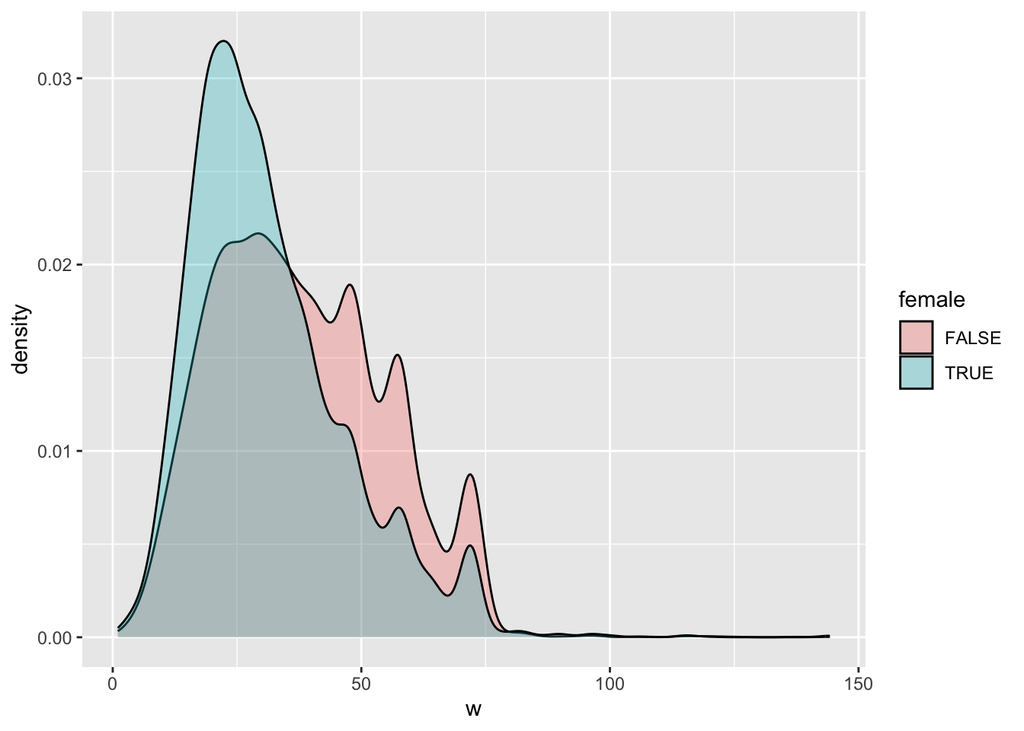

```r
# Densidad estimada diferenciada por género
ggplot(data = cps) + geom_density(aes(x = w, fill = female), alpha=0.3)
```

```r
# SALARIOS, EDAD Y GÉNERO
reg0 <- lm(log(w) ~ female, data=cps)
reg1 <- lm(log(w) ~ female + age, data=cps)
reg2 <- lm(log(w) ~ female*age, data=cps) # Interacción entre género y edad
reg21 <- lm(log(w) ~ age, data=cps %>% filter(female==1)) # Ec. mujeres
reg22 <- lm(log(w) ~ age, data=cps %>% filter(female==0)) # Ec. hombres
huxreg(reg0, reg1, reg2, reg21, reg22,
       statistics = c(N = "nobs", R2 = "r.squared"))
```

|  | (1) | (2) | (3) | (4) | (5) |
| --- | --- | --- | --- | --- | --- |
| (Intercept) | 3.522 *** | 3.196 *** | 3.117 *** | 3.081 *** | 3.117 *** |
|  | (0.006) | (0.017) | (0.023) | (0.021) | (0.023) |
| femaleTRUE | -0.193 *** | -0.182 *** | -0.036 |  |  |
|  | (0.008) | (0.008) | (0.032) |  |  |
| age |  | 0.007 *** | 0.009 *** | 0.006 *** | 0.009 *** |
|  |  | (0.000) | (0.001) | (0.000) | (0.001) |
| femaleTRUE:age |  |  | -0.003 *** |  |  |
|  |  |  | (0.001) |  |  |
| N | 18220 | 18220 | 18220 | 9672 | 8548 |
| R2 | 0.034 | 0.057 | 0.058 | 0.015 | 0.036 |
| *** p < 0.001; ** p < 0.01; * p < 0.05. |  |  |  |  |  |

```r
# No linealidad en la edad
cps <- cps %>% mutate(age2=age**2, age3=age**3, age4=age**4)
reg3 <- lm(log(w) ~ female + age + age2 + age3 + age4, data=cps)
huxreg(reg1, reg3, statistics = c(N = "nobs", R2 = "r.squared"))
```

|  | (1) | (2) |
| --- | --- | --- |
| (Intercept) | 3.196 *** | -3.131 ** |
|  | (0.017) | (1.059) |
| femaleTRUE | -0.182 *** | -0.180 *** |
|  | (0.008) | (0.007) |
| age | 0.007 *** | 0.525 *** |
|  | (0.000) | (0.103) |
| age2 |  | -0.016 *** |
|  |  | (0.004) |
| age3 |  | 0.000 *** |
|  |  | (0.000) |
| age4 |  | -0.000 ** |
|  |  | (0.000) |
| N | 18220 | 18220 |
| R2 | 0.057 | 0.079 |
| *** p < 0.001; ** p < 0.01; * p < 0.05. |  |  |

```r
# SALARIOS, SEXO, EDAD Y NIVEL DE EDUCACIÓN
cps <- cps %>% mutate(ed_MA=as.numeric(grade92==44),
                      ed_PSD = as.numeric(grade92==45),
                      ed_DD = as.numeric(grade92==46))
reg4 <- lm(log(w) ~ female + age + age2 + age3 + age4 + ed_PSD + ed_DD,
           data=cps)
huxreg(reg3, reg4, statistics = c(N = "nobs", R2 = "r.squared"))
```

|  | (1) | (2) |
| --- | --- | --- |
| (Intercept) | -3.131 ** | -2.789 ** |
|  | (1.059) | (1.052) |
| femaleTRUE | -0.180 *** | -0.167 *** |
|  | (0.007) | (0.007) |
| age | 0.525 *** | 0.491 *** |
|  | (0.103) | (0.102) |
| age2 | -0.016 *** | -0.014 *** |
|  | (0.004) | (0.004) |
| age3 | 0.000 *** | 0.000 *** |
|  | (0.000) | (0.000) |
| age4 | -0.000 ** | -0.000 ** |
|  | (0.000) | (0.000) |
| ed_PSD |  | 0.142 *** |
|  |  | (0.012) |
| ed_DD |  | 0.129 *** |
|  |  | (0.011) |
| N | 18220 | 18220 |
| R2 | 0.079 | 0.091 |
| *** p < 0.001; ** p < 0.01; * p < 0.05. |  |  |

```r
# SALARIOS, SEXO, EDAD, EDUCACIÓN Y OTROS FACTORES (CUALITATIVOS) CONDICIONANTES
# Construcción de factores condicionantes
# Factores demográficos (predeterminados)
cps <- cps %>% mutate(white=as.numeric(race==1),
                      afram = as.numeric(race==2),
                      asian = as.numeric(race==4),
                      hisp = !is.na(ethnic),
                      othernonw = as.numeric(white==0 & afram==0
                                             & asian==0 & hisp==0),
                      nonUSborn = as.numeric(
                        prcitshp=="Foreign Born, US Cit By Naturalization" |
                          prcitshp=="Foreign Born, Not a US Citizen")
)
# Factores demográficos (potencialmente endógenos)
cps <- cps %>% mutate(married = as.numeric(marital==1 | marital==2),
                      divorced = as.numeric(marital==3 | marital==5 |
                                              marital==6),
                      wirowed = as.numeric(marital==4),
                      nevermar = as.numeric(marital==7),
                      child0 = as.numeric(chldpres==0),
                      child1 = as.numeric(chldpres==1),
                      child2 = as.numeric(chldpres==2),
                      child3 = as.numeric(chldpres==3),
                      child4pl = as.numeric(chldpres>=4))
# Factores laborales
cps <- cps %>% mutate(fedgov = as.numeric(class=="Government - Federal"),
                      stagov = as.numeric(class=="Government - State"),
                      locgov = as.numeric(class=="Government - Local"),
                      nonprof = as.numeric(class=="Private, Nonprofit"),
                      ind2dig = as.integer(as.numeric(as.factor(ind02))/100),
                      occ2dig = as.integer(occ2012/100),
                      union = as.numeric(unionmme=="Yes" | unioncov=="Yes"))
# Regresión final con todas las variables de control
reg5 <- lm(log(w) ~ female
           + age + age2 + age3 + age4
           + ed_PSD + ed_DD
           + afram + hisp + asian + othernonw + nonUSborn
           + married + divorced + wirowed + child1 + child2 + child3 +child4pl
           + uhours + fedgov + stagov + locgov + nonprof + union
           + as.factor(stfips) + as.factor(ind2dig) + as.factor(occ2dig),
           data=cps)
summary(reg5)
```

```
Call:
lm(formula = log(w) ~ female + age + age2 + age3 + age4 + ed_PSD +
    ed_DD + afram + hisp + asian + othernonw + nonUSborn + married +
    divorced + wirowed + child1 + child2 + child3 + child4pl +
    uhours + fedgov + stagov + locgov + nonprof + union + as.factor(stfips) +
    as.factor(ind2dig) + as.factor(occ2dig), data = cps)

Residuals:
    Min      1Q  Median      3Q     Max
-3.6504 -0.2513  0.0367  0.2953  1.5951

Coefficients:
                       Estimate Std. Error t value Pr(>|t|)
(Intercept)           1.540e-01  9.778e-01   0.157 0.874859
femaleTRUE           -1.117e-01  7.428e-03 -15.034  < 2e-16 ***
age                   2.666e-01  9.527e-02   2.798 0.005141 **
age2                 -7.109e-03  3.390e-03  -2.097 0.036017 *
age3                  8.662e-05  5.222e-05   1.659 0.097183 .
age4                 -4.078e-07  2.942e-07  -1.386 0.165817
ed_PSD                7.534e-02  1.333e-02   5.653 1.60e-08 ***
ed_DD                 1.139e-01  1.166e-02   9.764  < 2e-16 ***
afram                -8.387e-02  1.337e-02  -6.272 3.65e-10 ***
hispTRUE             -2.341e-02  1.546e-02  -1.514 0.129996
asian                 2.119e-02  1.411e-02   1.502 0.133025
othernonw             2.047e-02  2.613e-02   0.783 0.433408
nonUSborn            -5.023e-02  1.161e-02  -4.328 1.51e-05 ***
married               6.139e-02  1.049e-02   5.852 4.95e-09 ***
divorced              5.025e-02  1.359e-02   3.697 0.000219 ***
wirowed               6.760e-02  3.606e-02   1.875 0.060876 .
child1                5.796e-02  1.665e-02   3.480 0.000502 ***
child2                1.093e-02  2.036e-02   0.537 0.591310
child3                2.589e-02  1.243e-02   2.083 0.037250 *
child4pl              2.769e-02  9.711e-03   2.851 0.004359 **
uhours               -4.568e-03  3.873e-04 -11.795  < 2e-16 ***
fedgov                8.580e-02  1.535e-02   5.588 2.33e-08 ***
stagov               -4.648e-02  1.272e-02  -3.654 0.000259 ***
locgov               -3.900e-02  1.312e-02  -2.974 0.002946 **
nonprof              -7.461e-02  1.075e-02  -6.939 4.08e-12 ***
union                 6.531e-02  1.067e-02   6.122 9.41e-10 ***
as.factor(stfips)AL  -2.471e-01  4.712e-02  -5.245 1.58e-07 ***
```

[output cut: 133 more lines]

```
as.factor(occ2dig)87 -4.341e-01  8.815e-02  -4.925 8.51e-07 ***
as.factor(occ2dig)88 -9.160e-01  1.599e-01  -5.727 1.04e-08 ***
as.factor(occ2dig)89 -4.953e-01  1.432e-01  -3.460 0.000542 ***
as.factor(occ2dig)90 -1.211e-01  8.998e-02  -1.345 0.178527
as.factor(occ2dig)91 -8.391e-01  6.843e-02 -12.263  < 2e-16 ***
as.factor(occ2dig)93 -9.595e-01  2.260e-01  -4.245 2.19e-05 ***
as.factor(occ2dig)94 -3.147e-01  1.711e-01  -1.839 0.065928 .
as.factor(occ2dig)96 -8.983e-01  1.212e-01  -7.408 1.34e-13 ***
as.factor(occ2dig)97 -1.182e+00  4.501e-01  -2.625 0.008669 **
---
Signif. codes:  0 '***' 0.001 '**' 0.01 '*' 0.05 '.' 0.1 ' ' 1

Residual standard error: 0.4488 on 18051 degrees of freedom
Multiple R-squared:  0.2641,    Adjusted R-squared:  0.2572
F-statistic: 38.56 on 168 and 18051 DF,  p-value: < 2.2e-16
```

**Código Python**

```python
# Lectura de librerías
import numpy as np
import pandas as pd
from plotnine import *
from scipy.stats import norm
import statsmodels.api as sm
import statsmodels.formula.api as smf
from mizani import transforms
from mizani.formatters import percent_format
from stargazer.stargazer import Stargazer
#
# FILTRADO PREVIO DE OBSERVACIONES:
#
# Operación sobre el fichero original: cps = pd.read_csv('data/MORG14_USA.csv')
# cps = cps.query("age>=24 & age<=64 & uhours>=20 & earnwke>0 & grade92>=44")
#
# Lectura de datos
cps = pd.read_csv('data/CPS2014_USA.csv')
# Operaciones con variables
cps["female"] = (cps.sex == 2).astype(int)
cps["w"] = cps["earnwke"] / cps["uhours"]
cps = cps.query("w>=1")
# Distribución de los salarios
cps.loc[:,["earnwke","uhours","w"]].describe()
```

```
            earnwke        uhours             w
count  18220.000000  18220.000000  18220.000000
mean    1483.491212     42.970088     34.565432
std      746.672256      9.135281     16.622801
min       38.000000     20.000000      1.025556
25%      923.000000     40.000000     21.634500
50%     1346.000000     40.000000     31.250000
75%     1923.070000     47.000000     45.673000
max     2884.610000     99.000000    144.230500
```

```python
# SALARIOS, SEXO Y EDAD
reg0 = smf.ols(formula="np.log(w) ~ female", data=cps).fit()
print(reg0.summary())
```

```
                            OLS Regression Results
==============================================================================
Dep. Variable:              np.log(w)   R-squared:                       0.034
Model:                            OLS   Adj. R-squared:                  0.034
Method:                 Least Squares   F-statistic:                     645.5
Date:                Sun, 09 Feb 2025   Prob (F-statistic):          5.68e-140
Time:                        13:31:57   Log-Likelihood:                -13647.
No. Observations:               18220   AIC:                         2.730e+04
Df Residuals:                   18218   BIC:                         2.731e+04
Df Model:                           1
Covariance Type:            nonrobust
==============================================================================
                 coef    std err          t      P>|t|      [0.025      0.975]
------------------------------------------------------------------------------
Intercept      3.5215      0.006    636.177      0.000       3.511       3.532
female        -0.1930      0.008    -25.407      0.000      -0.208      -0.178
==============================================================================
Omnibus:                     1256.924   Durbin-Watson:                   1.853
Prob(Omnibus):                  0.000   Jarque-Bera (JB):             1732.098
Skew:                          -0.603   Prob(JB):                         0.00
Kurtosis:                       3.910   Cond. No.                         2.70
==============================================================================

Notes:
[1] Standard Errors assume that the covariance matrix of the errors is correctly specified.
```

```
<Figure Size: (640 x 480)>
```

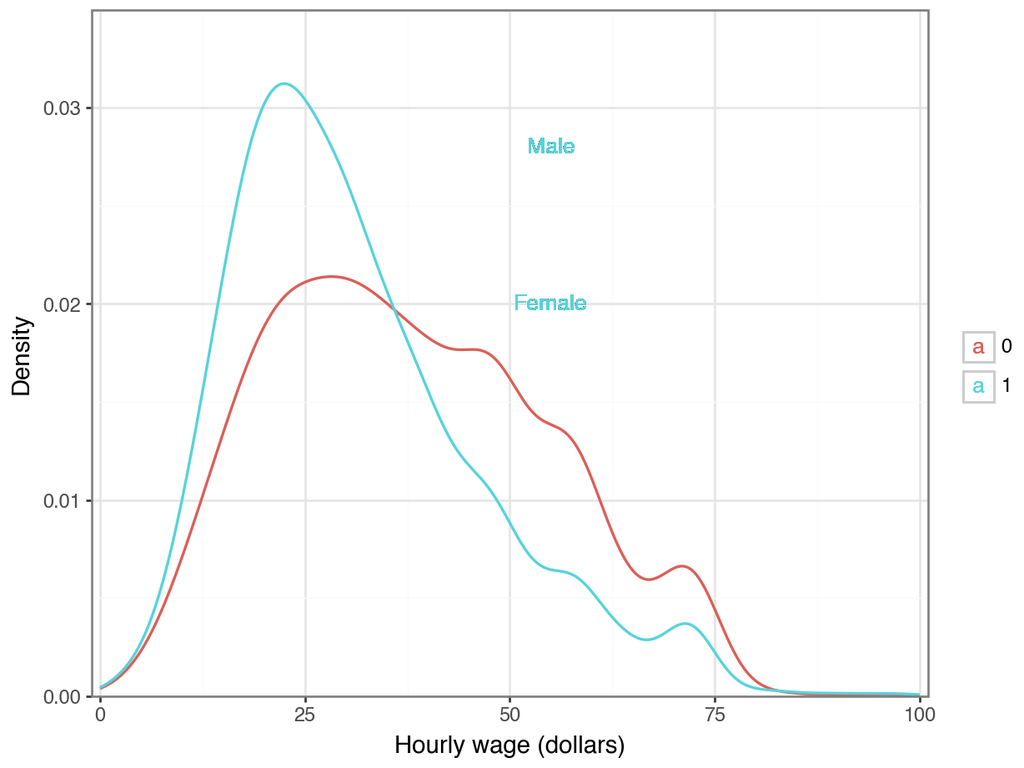

```python
# Densidad estimada diferenciada por género
ggplot(cps, aes(x="w", y="stat(density)", color="factor(female)")) + geom_density(
    adjust=1.5, show_legend=False, na_rm=True, size=0.7
) + labs(x="Hourly wage (dollars)", y="Density", color=""
)  + scale_x_continuous(
    expand=(0.01, 0.01), limits=(0, 100),
) + scale_y_continuous(
    expand=(0.0, 0.0), limits=(0, 0.035),
) + geom_text(
    aes(x=55, y=0.028, label="'Male'"),  size=10
) + geom_text(
    aes(x=55, y=0.020, label="'Female'"), size=10
) + theme_bw()
```

```python
# SALARIOS, EDAD Y GÉNERO
reg0 = smf.ols(formula="np.log(w) ~ female", data=cps).fit()
reg1 = smf.ols(formula="np.log(w) ~ female + age", data=cps).fit()
reg2 = smf.ols(formula="np.log(w) ~ female*age", data=cps).fit()
reg21 = smf.ols(formula="np.log(w) ~ age", data=cps.query("female==1")).fit()
reg22 = smf.ols(formula="np.log(w) ~ age", data=cps.query("female==0")).fit()
stargazer = Stargazer([reg0, reg1, reg2])
stargazer.custom_columns(["log(w)", "log(w)", "log(w)"], [1, 1, 1])
stargazer.covariate_order(["female", "age", "female:age", "Intercept"])
stargazer.rename_covariates({"Intercept": "Constant"})
stargazer
```

|  | *Dependent variable: np.log(w)* |  |  |
| --- | --- | --- | --- |
|  | log(w) | log(w) | log(w) |
|  | (1) | (2) | (3) |
| female | -0.193*** | -0.182*** | -0.036 |
|  | (0.008) | (0.008) | (0.032) |
| age |  | 0.007*** | 0.009*** |
|  |  | (0.000) | (0.001) |
| female:age |  |  | -0.003*** |
|  |  |  | (0.001) |
| Constant | 3.522*** | 3.196*** | 3.117*** |
|  | (0.006) | (0.017) | (0.023) |
| Observations | 18220 | 18220 | 18220 |
| R<sup>2</sup> | 0.034 | 0.057 | 0.058 |
| Adjusted R<sup>2</sup> | 0.034 | 0.057 | 0.058 |
| Residual Std. Error | 0.512 (df=18218) | 0.506 (df=18217) | 0.505 (df=18216) |
| F Statistic | 645.532*** (df=1; 18218) | 548.583*** (df=2; 18217) | 373.761*** (df=3; 18216) |
| Note: | *p<0.1; **p<0.05; ***p<0.01 |  |  |

```python
# Regresiones diferenciadas por sexo
print(reg21.summary())
```

```
                            OLS Regression Results
==============================================================================
Dep. Variable:              np.log(w)   R-squared:                       0.015
Model:                            OLS   Adj. R-squared:                  0.014
Method:                 Least Squares   F-statistic:                     143.3
Date:                Sun, 09 Feb 2025   Prob (F-statistic):           8.67e-33
Time:                        13:33:02   Log-Likelihood:                -7149.3
No. Observations:                9672   AIC:                         1.430e+04
Df Residuals:                    9670   BIC:                         1.432e+04
Df Model:                           1
Covariance Type:            nonrobust
==============================================================================
                 coef    std err          t      P>|t|      [0.025      0.975]
------------------------------------------------------------------------------
Intercept      3.0812      0.021    144.730      0.000       3.039       3.123
age            0.0057      0.000     11.970      0.000       0.005       0.007
==============================================================================
Omnibus:                      575.878   Durbin-Watson:                   1.904
Prob(Omnibus):                  0.000   Jarque-Bera (JB):              939.605
Skew:                          -0.483   Prob(JB):                    9.27e-205
Kurtosis:                       4.183   Cond. No.                         184.
==============================================================================

Notes:
[1] Standard Errors assume that the covariance matrix of the errors is correctly specified.
```

```python
print(reg22.summary())
```

```
                            OLS Regression Results
==============================================================================
Dep. Variable:              np.log(w)   R-squared:                       0.036
Model:                            OLS   Adj. R-squared:                  0.036
Method:                 Least Squares   F-statistic:                     317.4
Date:                Sun, 09 Feb 2025   Prob (F-statistic):           9.74e-70
Time:                        13:33:02   Log-Likelihood:                -6270.8
No. Observations:                8548   AIC:                         1.255e+04
Df Residuals:                    8546   BIC:                         1.256e+04
Df Model:                           1
Covariance Type:            nonrobust
==============================================================================
                 coef    std err          t      P>|t|      [0.025      0.975]
------------------------------------------------------------------------------
Intercept      3.1167      0.023    133.395      0.000       3.071       3.163
age            0.0091      0.001     17.815      0.000       0.008       0.010
==============================================================================
Omnibus:                      878.941   Durbin-Watson:                   1.886
Prob(Omnibus):                  0.000   Jarque-Bera (JB):             1248.166
Skew:                          -0.805   Prob(JB):                    9.21e-272
Kurtosis:                       3.956   Cond. No.                         197.
==============================================================================

Notes:
[1] Standard Errors assume that the covariance matrix of the errors is correctly specified.
```

```python
# No linealidad en la edad
cps["age2"] = np.power(cps["age"], 2)
cps["age3"] = np.power(cps["age"], 3)
cps["age4"] = np.power(cps["age"], 4)
reg3 = smf.ols(formula="np.log(w) ~ female + age + age2 + age3 + age4", data=cps).fit()
stargazer = Stargazer([reg1,reg3])
stargazer.covariate_order(
    ["female", "age", "age2","age3","age4","Intercept"]
)
stargazer.rename_covariates({"Intercept": "Constant"})
stargazer
```

|  | *Dependent variable: np.log(w)* |  |
| --- | --- | --- |
|  | (1) | (2) |
| female | -0.182*** | -0.180*** |
|  | (0.008) | (0.007) |
| age | 0.007*** | 0.525*** |
|  | (0.000) | (0.103) |
| age2 |  | -0.016*** |
|  |  | (0.004) |
| age3 |  | 0.000*** |
|  |  | (0.000) |
| age4 |  | -0.000*** |
|  |  | (0.000) |
| Constant | 3.196*** | -3.131*** |
|  | (0.017) | (1.059) |
| Observations | 18220 | 18220 |
| R<sup>2</sup> | 0.057 | 0.079 |
| Adjusted R<sup>2</sup> | 0.057 | 0.078 |
| Residual Std. Error | 0.506 (df=18217) | 0.500 (df=18214) |
| F Statistic | 548.583*** (df=2; 18217) | 310.523*** (df=5; 18214) |
| Note: | *p<0.1; **p<0.05; ***p<0.01 |  |

```python
# SALARIOS, SEXO, EDAD Y NIVEL DE EDUCACIÓN
cps["ed_MA"] = (cps["grade92"] == 44).astype(int)
cps["ed_PSD"] = (cps["grade92"] == 45).astype(int)
cps["ed_DD"] = (cps["grade92"] == 46).astype(int)
reg4 = smf.ols(formula="np.log(w) ~ female + age + age2 + age3 + age4 + ed_PSD + ed_DD", data=cps).fit()
stargazer = Stargazer([reg3,reg4])
stargazer.covariate_order(
    ["female", "age", "age2", "age3", "age4", "ed_PSD", "ed_DD", "Intercept"]
)
stargazer.rename_covariates({"Intercept": "Constant"})
stargazer
```

|  | *Dependent variable: np.log(w)* |  |
| --- | --- | --- |
|  | (1) | (2) |
| female | -0.180*** | -0.167*** |
|  | (0.007) | (0.007) |
| age | 0.525*** | 0.491*** |
|  | (0.103) | (0.102) |
| age2 | -0.016*** | -0.014*** |
|  | (0.004) | (0.004) |
| age3 | 0.000*** | 0.000*** |
|  | (0.000) | (0.000) |
| age4 | -0.000*** | -0.000*** |
|  | (0.000) | (0.000) |
| ed_PSD |  | 0.142*** |
|  |  | (0.012) |
| ed_DD |  | 0.129*** |
|  |  | (0.011) |
| Constant | -3.131*** | -2.789*** |
|  | (1.059) | (1.052) |
| Observations | 18220 | 18220 |
| R<sup>2</sup> | 0.079 | 0.091 |
| Adjusted R<sup>2</sup> | 0.078 | 0.091 |
| Residual Std. Error | 0.500 (df=18214) | 0.497 (df=18212) |
| F Statistic | 310.523*** (df=5; 18214) | 260.920*** (df=7; 18212) |
| Note: | *p<0.1; **p<0.05; ***p<0.01 |  |

```python
# SALARIOS, SEXO, EDAD, EDUCACIÓN Y OTROS FACTORES (CUALITATIVOS) CONDICIONANTES
# Construcción de factores condicionantes
cps["white"] = (cps["race"] == 1).astype(int)
cps["afram"] = (cps["race"] == 2).astype(int)
cps["asian"] = (cps["race"] == 4).astype(int)
cps["hisp"] = (cps["ethnic"].notna()).astype(int)
cps["othernonw"] = (
    (cps["white"] == 0) & (cps["afram"] == 0) & (cps["asian"] == 0) & (cps["hisp"] == 0)
).astype(int)
cps["nonUSborn"] = (
    (cps["prcitshp"] == "Foreign Born, US Cit By Naturalization")
    | (cps["prcitshp"] == "Foreign Born, Not a US Citizen")
).astype(int)
cps['married']=((cps['marital']==1)|(cps['marital']==2)).astype(int)
cps['divorced']=((cps['marital']==3)&(cps['marital']==5)).astype(int)
cps['wirowed']=(cps['marital']==4).astype(int)
cps['nevermar']=(cps['marital']==7).astype(int)
cps['child0']=(cps['chldpres']==0).astype(int)
cps['child1']=(cps['chldpres']==1).astype(int)
cps['child2']=(cps['chldpres']==2).astype(int)
cps['child3']=(cps['chldpres']==3).astype(int)
cps['child4pl']=(cps['chldpres']>=4).astype(int)
cps['fedgov']=(cps['class']=="Government - Federal").astype(int)
cps['stagov']=(cps['class']=="Government - State").astype(int)
cps['locgov']=(cps['class']=="Government - Local").astype(int)
cps['nonprof']=(cps['class']=="Private, Nonprofit").astype(int)
cps['ind2dig']=((pd.Categorical(cps["ind02"]).codes+1)/100).astype(int)
cps['occ2dig']=(cps["occ2012"]/100).astype(int)
cps['union']=((cps['unionmme']=="Yes")|(cps['unioncov']=="Yes")).astype(int)
# Regresión final con todas las variables de control
reg5 = smf.ols(formula="np.log(w) ~ female + age + age2 + age3 + age4 + ed_DD + afram + hisp + asian + othernonw + nonUSborn +  married + divorced+ wirowed + child1 + child2 + child3 + child4pl + uhours + fedgov + stagov + locgov + nonprof + union + C(stfips) + C(ind2dig) + C(occ2dig)", data=cps).fit()
print(reg5.summary())
```

```
                            OLS Regression Results
==============================================================================
Dep. Variable:              np.log(w)   R-squared:                       0.262
Model:                            OLS   Adj. R-squared:                  0.255
Method:                 Least Squares   F-statistic:                     38.65
Date:                Sun, 09 Feb 2025   Prob (F-statistic):               0.00
Time:                        13:33:03   Log-Likelihood:                -11194.
No. Observations:               18220   AIC:                         2.272e+04
Df Residuals:                   18053   BIC:                         2.403e+04
Df Model:                         166
Covariance Type:            nonrobust
====================================================================================
                       coef    std err          t      P>|t|      [0.025      0.975]
------------------------------------------------------------------------------------
Intercept           -0.0673      0.978     -0.069      0.945      -1.984       1.849
C(stfips)[T.AL]     -0.2414      0.047     -5.120      0.000      -0.334      -0.149
C(stfips)[T.AR]     -0.2050      0.053     -3.846      0.000      -0.309      -0.101
C(stfips)[T.AZ]     -0.1295      0.046     -2.787      0.005      -0.221      -0.038
C(stfips)[T.CA]      0.0396      0.035      1.132      0.258      -0.029       0.108
C(stfips)[T.CO]     -0.0921      0.039     -2.358      0.018      -0.169      -0.016
C(stfips)[T.CT]      0.0258      0.039      0.669      0.504      -0.050       0.101
C(stfips)[T.DC]      0.1292      0.037      3.526      0.000       0.057       0.201
C(stfips)[T.DE]     -0.0844      0.044     -1.934      0.053      -0.170       0.001
C(stfips)[T.FL]     -0.1402      0.038     -3.679      0.000      -0.215      -0.065
C(stfips)[T.GA]     -0.1023      0.041     -2.519      0.012      -0.182      -0.023
C(stfips)[T.HI]     -0.1536      0.045     -3.414      0.001      -0.242      -0.065
C(stfips)[T.IA]     -0.1879      0.044     -4.275      0.000      -0.274      -0.102
C(stfips)[T.ID]     -0.1747      0.049     -3.538      0.000      -0.272      -0.078
C(stfips)[T.IL]     -0.0804      0.038     -2.138      0.033      -0.154      -0.007
C(stfips)[T.IN]     -0.1358      0.046     -2.953      0.003      -0.226      -0.046
C(stfips)[T.KS]     -0.1681      0.042     -3.972      0.000      -0.251      -0.085
C(stfips)[T.KY]     -0.2147      0.045     -4.791      0.000      -0.303      -0.127
C(stfips)[T.LA]     -0.1534      0.048     -3.204      0.001      -0.247      -0.060
C(stfips)[T.MA]     -0.0010      0.039     -0.026      0.979      -0.078       0.076
C(stfips)[T.MD]     -0.0354      0.038     -0.939      0.348      -0.109       0.039
C(stfips)[T.ME]     -0.1641      0.044     -3.772      0.000      -0.249      -0.079
C(stfips)[T.MI]     -0.0647      0.040     -1.600      0.110      -0.144       0.015
C(stfips)[T.MN]     -0.0491      0.040     -1.241      0.215      -0.127       0.028
C(stfips)[T.MO]     -0.1121      0.044     -2.571      0.010      -0.198      -0.027
C(stfips)[T.MS]     -0.1887      0.049     -3.827      0.000      -0.285      -0.092
```

[output cut: 138 more lines]

```
stagov              -0.0457      0.013     -3.589      0.000      -0.071      -0.021
locgov              -0.0395      0.013     -3.006      0.003      -0.065      -0.014
nonprof             -0.0744      0.011     -6.914      0.000      -0.096      -0.053
union                0.0643      0.011      6.021      0.000       0.043       0.085
==============================================================================
Omnibus:                     2235.211   Durbin-Watson:                   1.947
Prob(Omnibus):                  0.000   Jarque-Bera (JB):             5280.553
Skew:                          -0.725   Prob(JB):                         0.00
Kurtosis:                       5.204   Cond. No.                     1.32e+16
==============================================================================

Notes:
[1] Standard Errors assume that the covariance matrix of the errors is correctly specified.
[2] The smallest eigenvalue is 4.69e-15. This might indicate that there are
strong multicollinearity problems or that the design matrix is singular.
```

```python
# COMPARACIÓN FINAL
stargazer = Stargazer([reg0, reg5])
stargazer.covariate_order(["female"])
stargazer.add_line("Edad y educación", ["", "Yes"])
stargazer.add_line("Características familliares", ["", "Yes"])
stargazer.add_line("Características demográficas", ["", "Yes"])
stargazer.add_line("Características laborales", ["", "Yes"])
stargazer
```

|  | *Dependent variable: np.log(w)* |  |
| --- | --- | --- |
|  | (1) | (2) |
| female | -0.193*** | -0.112*** |
|  | (0.008) | (0.007) |
| Edad y educación |  | Yes |
| Características familliares |  | Yes |
| Características demográficas |  | Yes |
| Características laborales |  | Yes |
| Observations | 18220 | 18220 |
| R<sup>2</sup> | 0.034 | 0.262 |
| Adjusted R<sup>2</sup> | 0.034 | 0.255 |
| Residual Std. Error | 0.512 (df=18218) | 0.449 (df=18053) |
| F Statistic | 645.532*** (df=1; 18218) | 38.651*** (df=166; 18053) |
| Note: | *p<0.1; **p<0.05; ***p<0.01 |  |

# Variables de alta frecuencia y con estacionalidad: Demanda de electricidad en el estado australiano de Victoria

En esta aplicación se estimará una función de demanda de electricidad para el estado de Victoria, en Australia. Se explicará el consumo de electricidad en función de la temperatura y de otras variables de control, usando datos semi-horarios (cada media hora) para el período 2012-2014.

Desde el punto de vista técnico se verán los problemas a los que se enfrenta el económetra al tratar con datos de frecuencia alta que además poseen distintos tipos de estacionalidad de forma simultánea.

**Código R**

```r
# Lectura de librerías
library(tidyverse)
library(fpp3)
# Lectura de datos
load("data/DEM_ELEC.RData")
class(dem_elec_vict)
```

```
[1] "tbl_ts"     "tbl_df"     "tbl"        "data.frame"
```

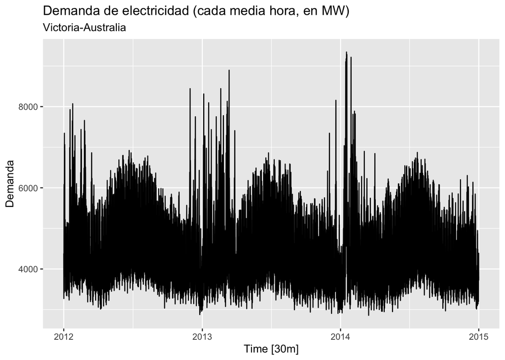

```r
# Demanda de electricidad 2012-2014
dem_elec_vict %>%
  autoplot(Demanda) +
  labs(title = "Demanda de electricidad (cada media hora, en MW)",
       subtitle = "Victoria-Australia")
```

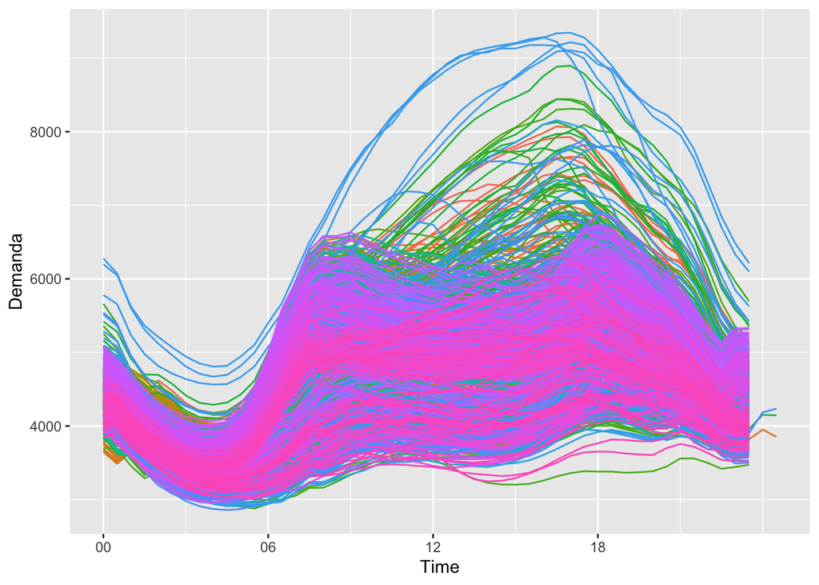

```r
# Estacionalidad(es) en la demanda
# Diaria
dem_elec_vict %>% gg_season(Demanda, period="day") +
  theme(legend.position = "none")
```

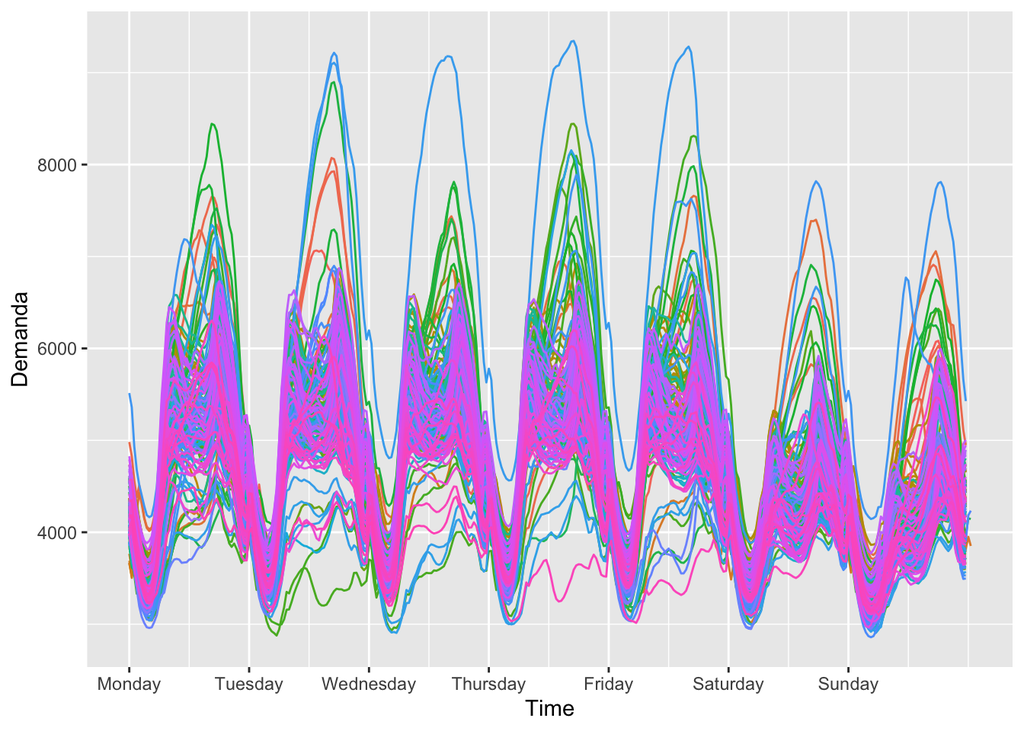

```r
# Semanal
dem_elec_vict %>% gg_season(Demanda, period="week") +
  theme(legend.position = "none")
```

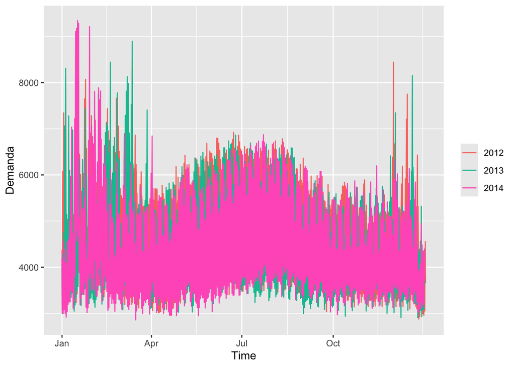

```r
# Mensual
dem_elec_vict %>% gg_season(Demanda, period="year")
```

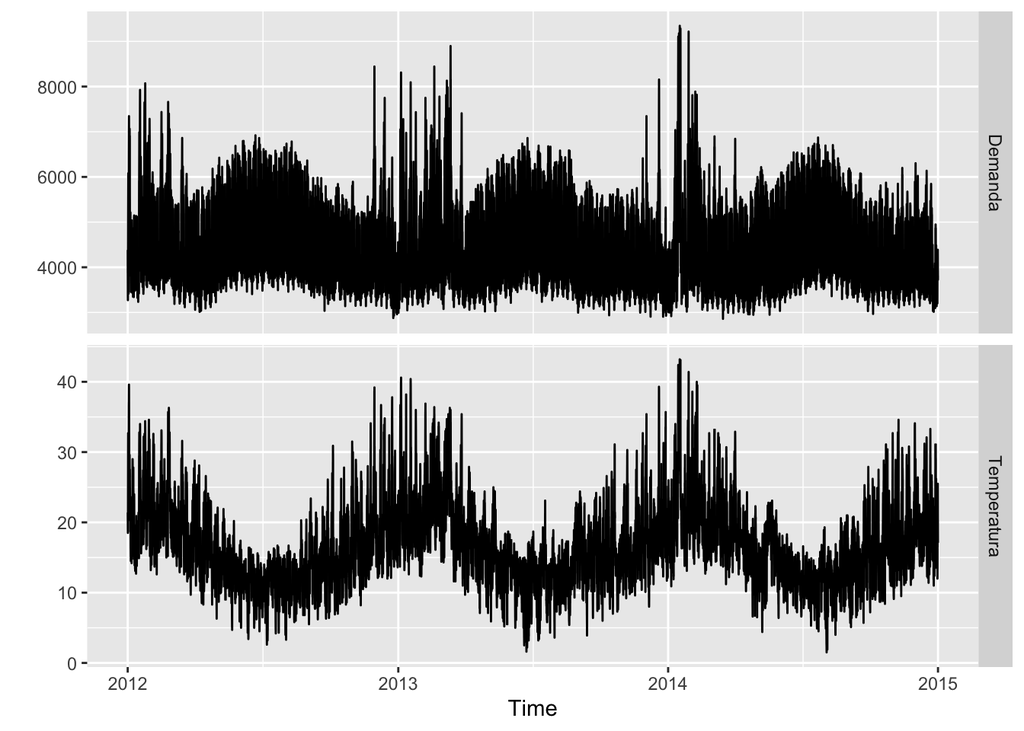

```r
# Consumo y temperatura en el período 2012-2014
dem_elec_vict %>%
  pivot_longer(Demanda:Temperatura, names_to = "Series") %>%
  ggplot(aes(x = Time, y = value)) +
  geom_line() +
  facet_grid(rows = vars(Series), scales = "free_y") +
  labs(y = "")
```

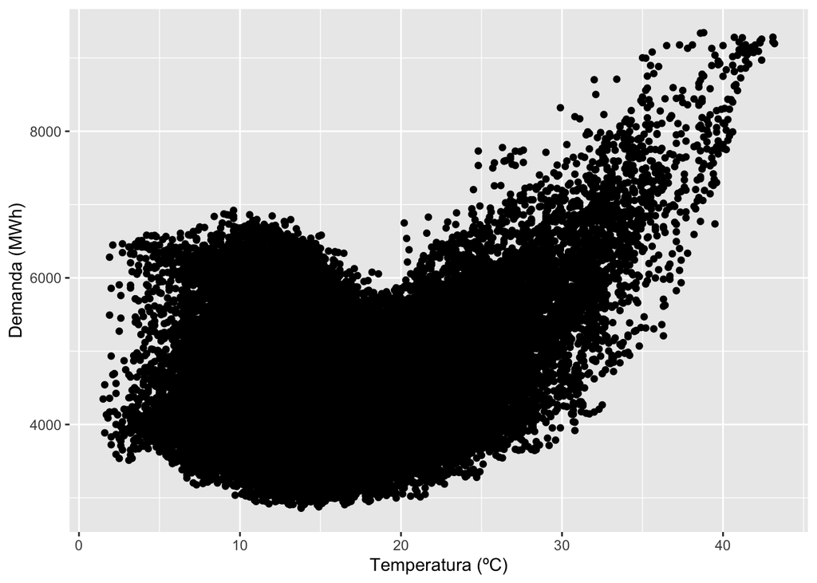

```r
# Consumo versus temperatura
dem_elec_vict %>%
  ggplot(aes(x = Temperatura, y = Demanda)) +
  geom_point() +
  ylab("Demanda (MWh)") + xlab("Temperatura (ºC)")
```

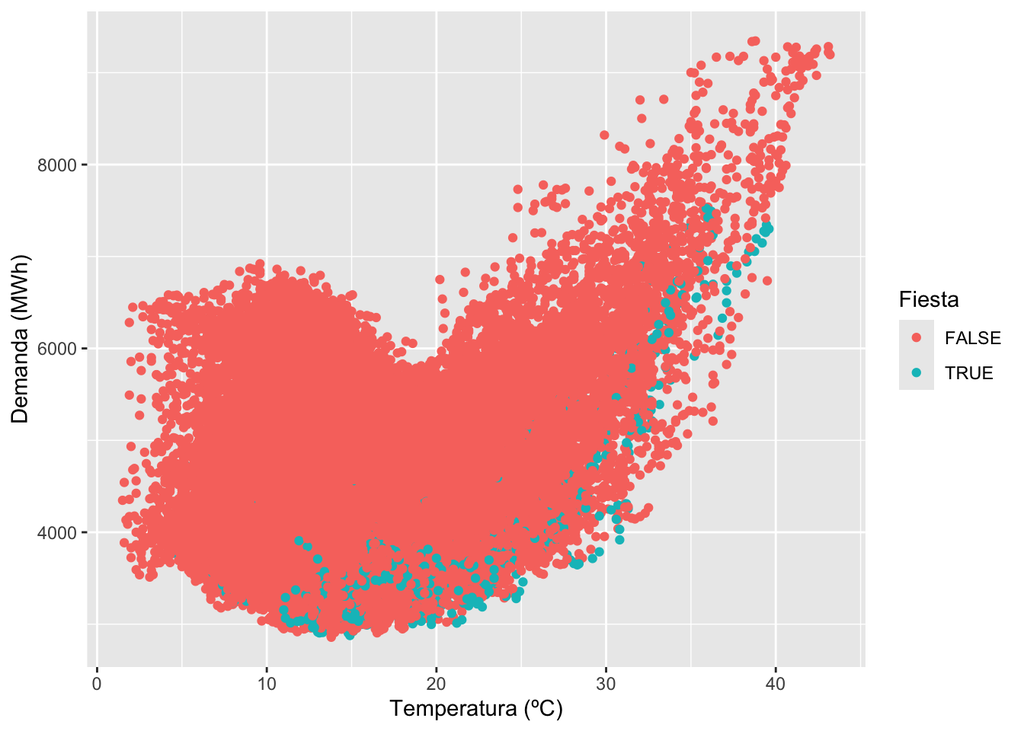

```r
# Comportamiento en días festivos
dem_elec_vict %>%
  ggplot(aes(x = Temperatura, y = Demanda, col=Fiesta)) +
  geom_point() +
  ylab("Demanda (MWh)") + xlab("Temperatura (ºC)")
```

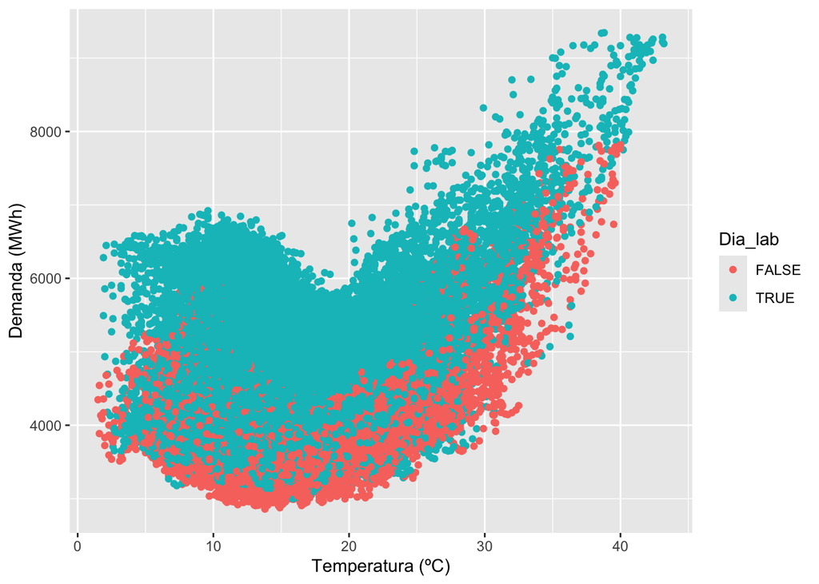

```r
# Comportamiento en días laborables
dem_elec_vict %>%
  ggplot(aes(x = Temperatura, y = Demanda, col=Dia_lab)) +
  geom_point() +
  ylab("Demanda (MWh)") + xlab("Temperatura (ºC)")
```

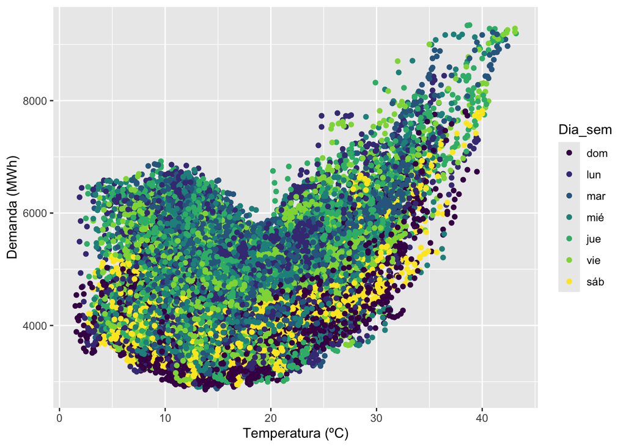

```r
# Comportamiento por día de la semana
dem_elec_vict %>%
  ggplot(aes(x = Temperatura, y = Demanda, col=Dia_sem)) +
  geom_point() +
  ylab("Demanda (MWh)") + xlab("Temperatura (ºC)")
```

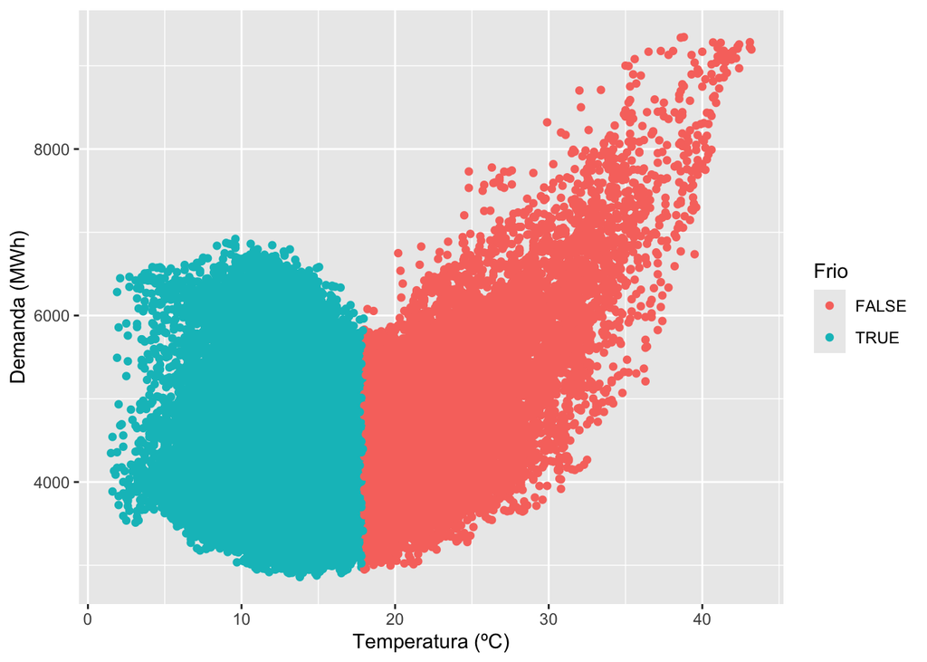

```r
# Comportamiento en días de frío (< 18ºC)
dem_elec_vict %>%
  ggplot(aes(x = Temperatura, y = Demanda, col=Frio)) +
  geom_point() +
  ylab("Demanda (MWh)") + xlab("Temperatura (ºC)")
```

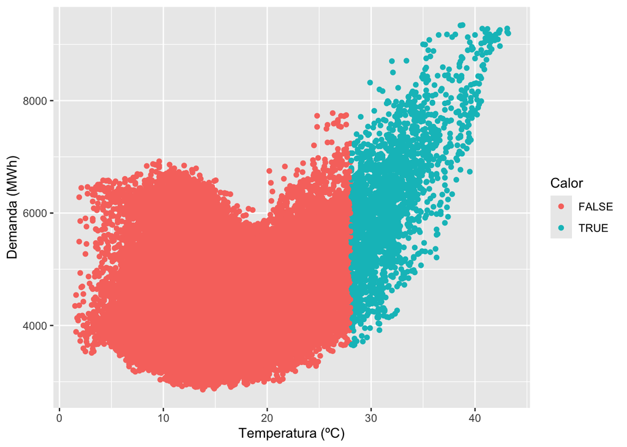

```r
# Comportamiento en días de calor (> 28ºC)
dem_elec_vict %>%
  ggplot(aes(x = Temperatura, y = Demanda, col=Calor)) +
  geom_point() +
  ylab("Demanda (MWh)") + xlab("Temperatura (ºC)")
```

```r
# Modelo de demanda de electricidad
dem_elec <- lm(log(Demanda) ~ Temperatura + I(Temperatura^2) +
                 Dia_sem + Dia_lab + Frio + Calor,
               data = dem_elec_vict)
summary(dem_elec)
```

```
Call:
lm(formula = log(Demanda) ~ Temperatura + I(Temperatura^2) +
    Dia_sem + Dia_lab + Frio + Calor, data = dem_elec_vict)

Residuals:
     Min       1Q   Median       3Q      Max
-0.45248 -0.11107  0.02178  0.10933  0.45429

Coefficients:
                   Estimate Std. Error  t value Pr(>|t|)
(Intercept)       8.449e+00  7.152e-03 1181.348  < 2e-16 ***
Temperatura      -2.707e-02  6.515e-04  -41.551  < 2e-16 ***
I(Temperatura^2)  9.218e-04  1.943e-05   47.439  < 2e-16 ***
Dia_sem.L         2.621e-02  1.783e-03   14.695  < 2e-16 ***
Dia_sem.Q         5.527e-02  4.781e-03   11.561  < 2e-16 ***
Dia_sem.C         1.388e-02  1.784e-03    7.779 7.43e-15 ***
Dia_sem^4         3.442e-02  2.557e-03   13.462  < 2e-16 ***
Dia_sem^5         6.508e-03  1.783e-03    3.650 0.000263 ***
Dia_sem^6         8.708e-03  1.796e-03    4.849 1.25e-06 ***
Dia_labTRUE       2.089e-01  4.179e-03   49.986  < 2e-16 ***
FrioTRUE          4.844e-03  2.500e-03    1.937 0.052713 .
CalorTRUE         5.543e-02  6.256e-03    8.859  < 2e-16 ***
---
Signif. codes:  0 '***' 0.001 '**' 0.01 '*' 0.05 '.' 0.1 ' ' 1

Residual standard error: 0.1544 on 52596 degrees of freedom
Multiple R-squared:  0.3044,    Adjusted R-squared:  0.3043
F-statistic:  2093 on 11 and 52596 DF,  p-value: < 2.2e-16
```

**Código Python**

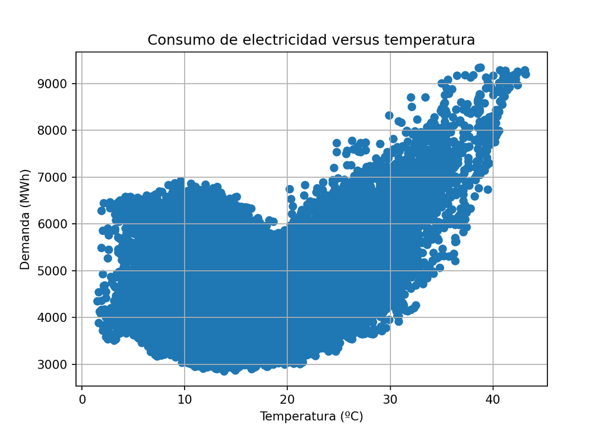

```python
# Lectura de librerías
import numpy as np
import pandas as pd
import matplotlib.pyplot as plt
import statsmodels.formula.api as smf
# Lectura de datos
dem_elec_vict = pd.read_csv('data/DEM_ELEC.csv', index_col=0)
# Gráfica consumo versus temperatura
plt.figure(3)
plt.scatter(dem_elec_vict['Temperatura'], dem_elec_vict['Demanda'])
plt.xlabel('Temperatura (ºC)')
plt.ylabel('Demanda (MWh)')
plt.title('Consumo de electricidad versus temperatura')
plt.grid(True)
plt.show()
```

```python
# Modelo de demanda de electricidad
dem_elec = smf.ols('np.log(Demanda) ~ Temperatura + np.power(Temperatura,2) + Dia_sem + Dia_lab + Frio + Calor', data=dem_elec_vict).fit()
print(dem_elec.summary())
```

```
                            OLS Regression Results
==============================================================================
Dep. Variable:        np.log(Demanda)   R-squared:                       0.304
Model:                            OLS   Adj. R-squared:                  0.304
Method:                 Least Squares   F-statistic:                     2093.
Date:                Sun, 09 Feb 2025   Prob (F-statistic):               0.00
Time:                        13:33:35   Log-Likelihood:                 23634.
No. Observations:               52608   AIC:                        -4.724e+04
Df Residuals:                   52596   BIC:                        -4.714e+04
Df Model:                          11
Covariance Type:            nonrobust
============================================================================================
                               coef    std err          t      P>|t|      [0.025      0.975]
--------------------------------------------------------------------------------------------
Intercept                    8.4662      0.007   1257.558      0.000       8.453       8.479
Dia_sem[T.jue]              -0.0257      0.005     -5.368      0.000      -0.035      -0.016
Dia_sem[T.lun]              -0.0401      0.005     -8.696      0.000      -0.049      -0.031
Dia_sem[T.mar]              -0.0314      0.005     -6.585      0.000      -0.041      -0.022
Dia_sem[T.mié]              -0.0307      0.005     -6.419      0.000      -0.040      -0.021
Dia_sem[T.sáb]               0.0425      0.003     16.853      0.000       0.038       0.047
Dia_sem[T.vie]              -0.0373      0.005     -7.820      0.000      -0.047      -0.028
Dia_lab[T.True]              0.2089      0.004     49.986      0.000       0.201       0.217
Frio[T.True]                 0.0048      0.003      1.937      0.053   -5.68e-05       0.010
Calor[T.True]                0.0554      0.006      8.859      0.000       0.043       0.068
Temperatura                 -0.0271      0.001    -41.551      0.000      -0.028      -0.026
np.power(Temperatura, 2)     0.0009   1.94e-05     47.439      0.000       0.001       0.001
==============================================================================
Omnibus:                     1844.730   Durbin-Watson:                   0.055
Prob(Omnibus):                  0.000   Jarque-Bera (JB):             1308.893
Skew:                          -0.282   Prob(JB):                    5.99e-285
Kurtosis:                       2.472   Cond. No.                     5.87e+03
==============================================================================

Notes:
[1] Standard Errors assume that the covariance matrix of the errors is correctly specified.
[2] The condition number is large, 5.87e+03. This might indicate that there are
strong multicollinearity or other numerical problems.
```